# Is Bitcoin overrated?

In the early ages of humanity, people already love to interchange every kind of things they have crafted or found. Soon was found that a general mean of exchange (what we understand as *currency*) made trades far more feasible and efficient. Many curious things have served as currencies throughout history: sea shells, cows, cigarettes or even noodles packs.

It is obvious that when currency is established as the standard mean of exchange, its value sky-rockets. And those who already possessed some of that currency might become utterly rich overnight.

The whole point of mercantilism and the added value of trade is the efficiency of the market, where the needs and capabilities of many unconnected people can be met by the means of a common desire: their currency. Following that logic, the value of a currency can be gauged out of the usage it has on the people. Welath is not constructed by the interchange of goods between two very rich men, but with the continuous small-scale negotiation of millions of people, balancing the forces of the market. So, whenever any currency does not fulfill this funcitonality or its purpose is in doubt, non benefiting the mass, new alternatives are always put on the table.

In the past decades, some branches of economy have argued that the lack of a gold standard, or any kind of objective and non-manipulable metric of wealth is leading the worldwide economy into a Ponzi scheme trap of ever-growing debt. Moreover, survivalists and conspiracy theorists love the gold standard, because it holds for them the promise of an ever-lasting stable currency in a governmental vacuum scenario. And it also prevents an out-of-hand money supply from the government, what could prevent disasters as the recent [hyperinflation of Zimbawe](https://en.wikipedia.org/wiki/Hyperinflation#Most_severe_hyperinflations_in_world_history).

Despite that, some argue that the Gold Standard would not be the all-saver of todays economic dangers. Today’s world is not the same as the world from a couple centuries ago; and today’s issues can not be so easily addressed with a shiny piece of metal. Gold coins can very susceptible to scams; has little or no intrinsic value in our current society and it might be not of enough of that [precious](https://en.wikipedia.org/wiki/Gollum) metal for sustaining all world’s economy. Some even discuss that *it lacks of nutritional value*, and that in a survavilist nightmare gold should be far down on the list of things to stuff in the bag before fleeing into the wilds.

Considering all of the above, seems reasonable the current eagerness in spotting beforehand whether some good is to become the [new gold](https://en.wikipedia.org/wiki/Bitcoin) of our era.

Over the past couple of years, we have witnessed an outstandingly sharp increase in bitcoin’s value. This has sparkled a bunch of discussion over whether it is a bubble or not, and over its real value.

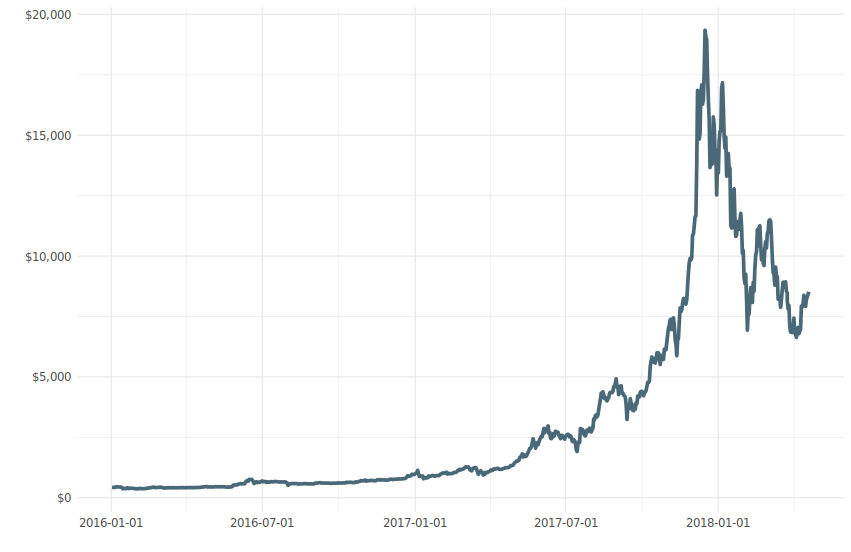

Unlike most stocks, bitcoin is uncapable of provide returns. It is not uncapable because it is not working properly, it is because it was never inteded to produce any kind of profit, it was inteded to become *a currency*. And no currency byproducts profits by itself.

Taking that into account, we must concede that the only value bitcoin has to offer it is its usage as a currency. So in order to assess whether it is overrated or not, we need to reckon a value, based on its feasability of becoming a mainstream currency.

# Can Bitcoin be a currency?

In general, a currency needs to fulfill three crucial characteristics: It has to be useful as a means of exchange, it needs to store value and it needs to be a unit of account.

## Mean of Exchange

Have you ever tried to buy something using *bitcoins*? Would you accept a payment on bitcoins?

These are the main question to be answered on this issue. It will be a mean of exchange when it is used as a mean of exchange, when it proves it is useful for that. And bitcoin has a great advantage over physical currencies: Because of its digital origin and nature, bitcoins can be splitted in as tiny pieces as its needed; you can always add another 0 to a string of numbers. This might sound trivial, but it is not, and it is a logistic and thecnical problem, and a constraint for physical fiat currencies.

Nowadays, bitcoins are sometimes used to buy and sell goods. Bitcoin is oftenly used as an alternative method of converting currencies, and to avoid the big banks that thend to charge amazingly high fees upon currencies exchange. It is also used in a variety of transactions that require some degree of secrecy; which could be awesome for most anarchists.

So yes, you can fairly think that bitcoin could be pretty useful as a mean of exchange.

# Storing Value

This point is intended to be the flagship of the bitcoin’s movement. This is the one where a lot of bitcoin’s defenders are putting their hats on.

When greedy governments become too reckless, it is no rare to see them printing money. A lot of money. Printing money has the collateral effect of devaluating the currency, leading to artificial inflation; which could eventually go downhill and trigger hyperinflation. These kind of scenarios jeopardizes the storage of wealth, the savings of the population and thus the confidence in that currency. If people does not belive in the reliability of their money and its value, they don’t save up. If you wouldn’t know how much your money would value tomorrow you’d be better spending anything on more reliable, durable and useful goods; such as houses, lands, livestock or whatever.

The algorithms and technology designed beneath bitcoin intends to put a cap on how many bitcoins can exist and be created. This simple characteristics puts a great fence for those governemtns, difficulting their self-destructive behaviour and stabilizing the value of money.

This puts bitcoin in an awesome situation, doesn’t it?

The truth is that printing money is not the only way to destabilize the value of a currency. Volatility does it too.

In the following plot, you will see computed the moving relative volatility of bitcoin and a bunch of standard fiat currencies.

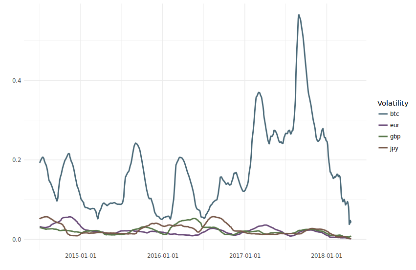